# Mapping and Measuring Residential Segregation

Arpita Banerjee.

3/19/2021

# 1. Introduction

The data used in the following analysis has been taken from the US Census Bureau, American Community Survey for 5 year periods. All the tables have been directly imported into R through Tidycensus.

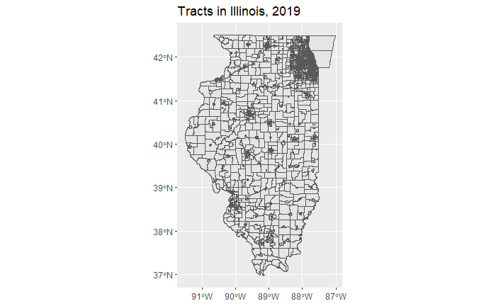

## 1.1. Chicago Metropolitan Region

The primary aim of this analysis is to understand how households are segregated in the Chicago Metropolitan Region, spanning the following counties

Cook County - 031, DeKalb - 037, DuPage - 043, Grundy - 063, Kane - 089, Kendall - 093, Lake - 097, McHenry - 111 , Will - 197

Several tracts within the aforementioned counties are uninhabited and are therefore removed from the analysis of housing segregation.

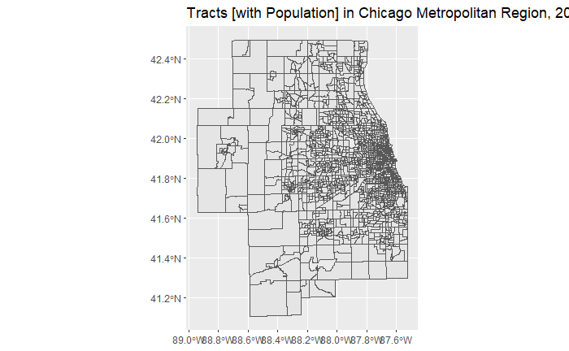

# 2. Distribution of Racial Groups

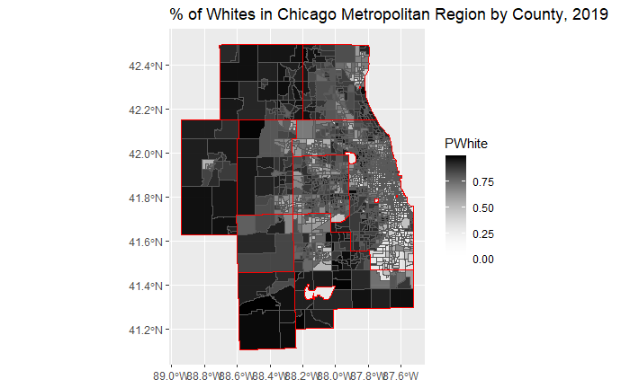

It can be observed here that there is a high percentage of white population throughout the metropolitan area, especially towards the Western and Southern parts of the region. Whites represent a majority within the metropolitan region.

## 2.1. Mapping Racial Minorities In Chicago Metropolitan Region

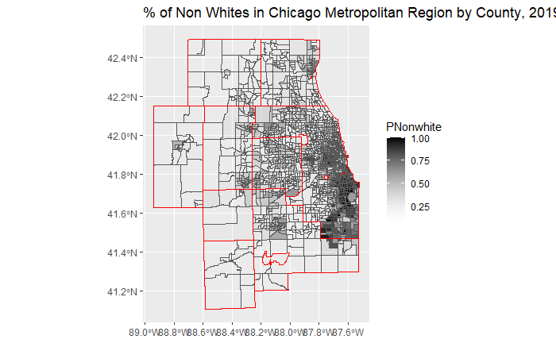

There is a significant difference between the number of whites and non-whites in the city. Non-whites are a minority and are mostly present in the Eastern part of the metropolitan region where the white population is comparatively low.

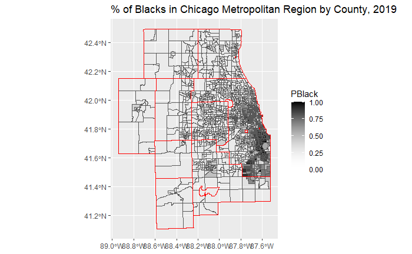

Blacks represent one of the largest minority groups in the area occupying mostly the east and south eastern parts of the region.

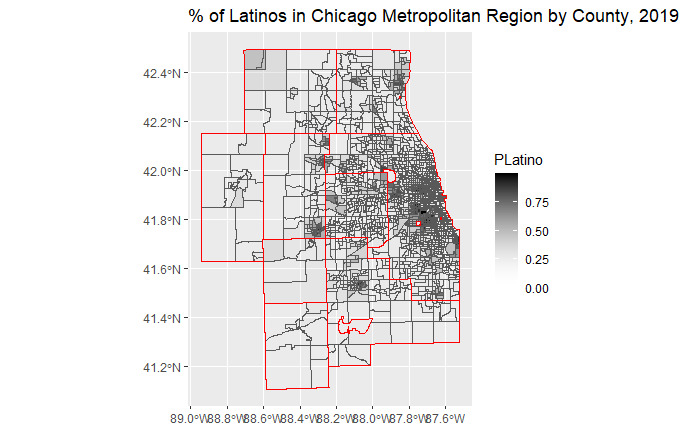

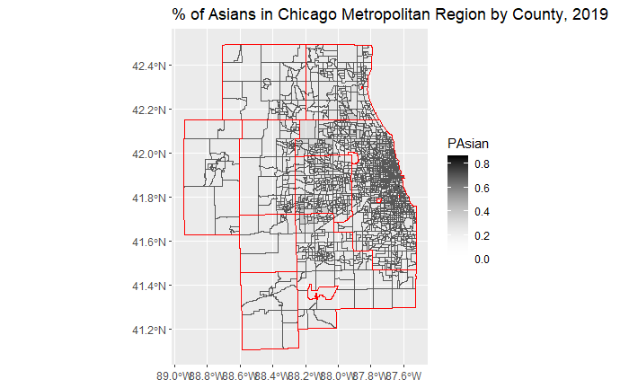

Asians are less preponderant than Blacks or Latinos and are localized in the eastern parts of the region, along with other persons of colour.

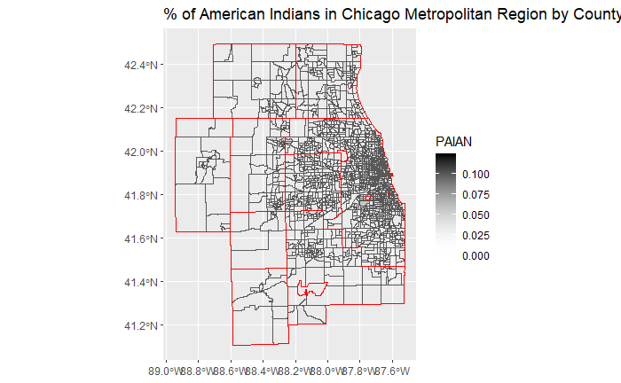

It is difficult to delineate any particular area within the metropolitan region at this level of resolution where American Indians are most commonly located. They represent the smallest minority group within the city.

## 2.2. Comparing Relative Distribution of Different Racial Groups

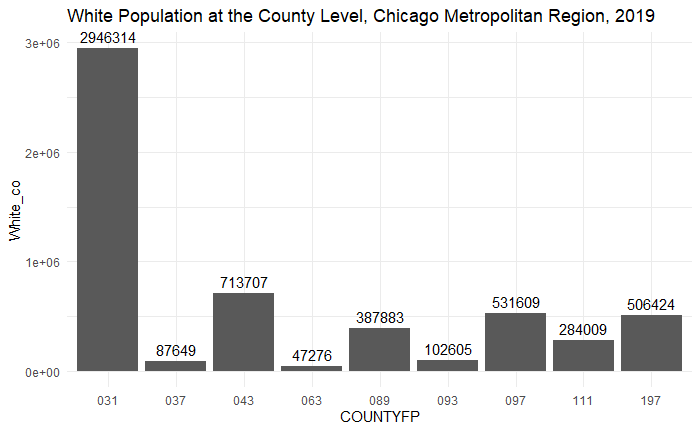

The White population is substantially high in the metropolitan region.

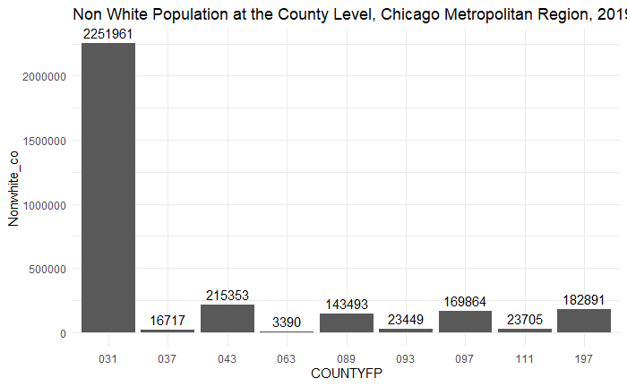

In general , the population in counties 037, 063 and 093 are substantially low. Highest number of people are found in the city / Cook County - 031, followed by 043.

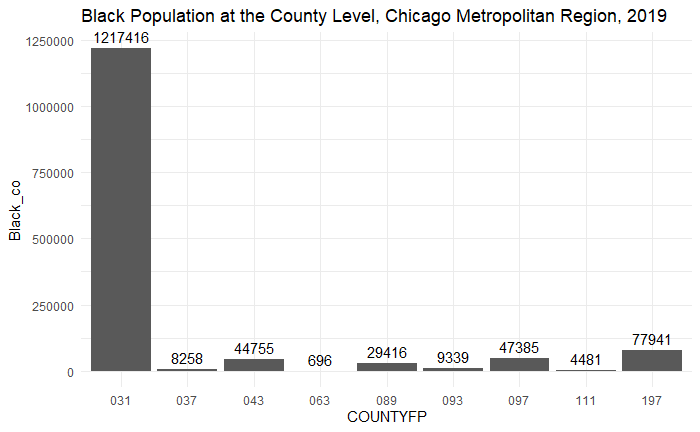

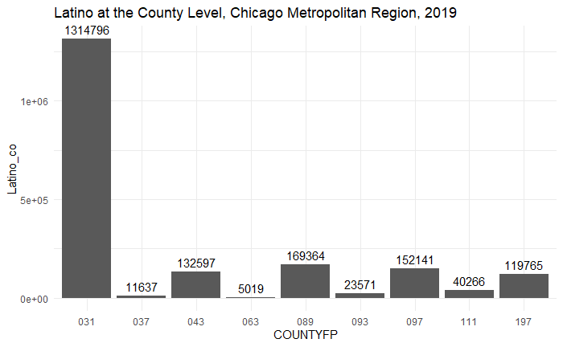

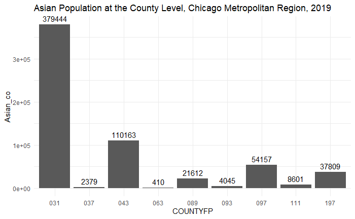

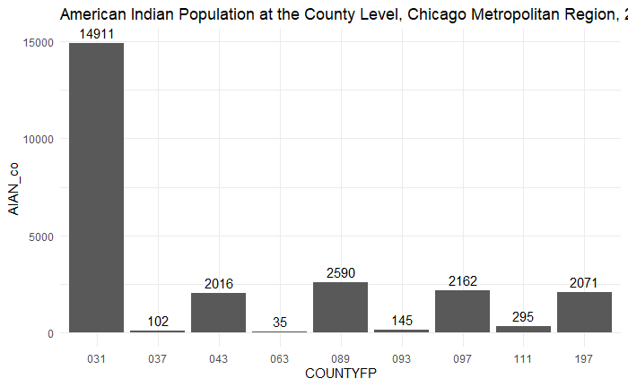

# 3. Understanding Housing Segregation

In order to understand housing segregation, there different measurements are taken. They are dissimilarity, interaction and isolation. There are described below.

## 3.1. Majority/Minority Dissimilarity

*Dissimilarity* is a common measure of *evenness* between two populations - dissimilarity measures the distribution of a minority population within a majority population. Conceptually, dissimilarity measures the proportion of that minority or subgroup population that would need to move in order to be equally distributed with the majority population. Dissimilarity is calculated as follows:

$D = .5*\sum_i |\frac{b_i}{B}-\frac{w_i}{W}|$ where $b_i$ is the number of blacks in tract *i* $B$ is the number of blacks for the county $w_i$ is the number of whites in tract *i* $W$ is the number of whites for the county

The dissimilarity values for all majority-minority groups are discussed below -

| COUNTYFP | dissimilarity_NonWhite_White | dissimilarity_Black_White | dissimilarity_Latino_White | dissimilarity_Asian_White | dissimilarity_AIAN_White |
| --- | --- | --- | --- | --- | --- |
| 031 | 0.4912424 | 0.7578794 | 0.4411871 | 0.4502416 | 0.7055028 |
| 037 | 0.3966881 | 0.5295320 | 0.2048503 | 0.4788275 | 0.7896119 |
| 043 | 0.2979487 | 0.3879989 | 0.3867571 | 0.3585515 | 0.7228637 |
| 063 | 0.2889747 | 0.3819132 | 0.2215250 | 0.4256758 | 0.4779912 |
| 089 | 0.3768448 | 0.4353399 | 0.4617327 | 0.3573122 | 0.6393568 |
| 093 | 0.2377866 | 0.2309396 | 0.1344544 | 0.4682907 | 0.5680133 |
| 097 | 0.3512554 | 0.5642134 | 0.4624586 | 0.3967334 | 0.6858415 |
| 111 | 0.2466268 | 0.3923875 | 0.2092301 | 0.4318553 | 0.7739015 |
| 197 | 0.4223635 | 0.5182092 | 0.4158243 | 0.5481525 | 0.6951220 |

## 3.2. Interaction Between Different Racial Groups

A second common measure of segregation is *interaction* which is a measure of *exposure*. Interaction measures the likelihood of population subgroups interacting with one another based upon their distribution within areal sub units (tracts). For instance, Black-White interaction is calculated as follows:

$Interaction = \sum_i\frac{b_i}{B}*\frac{w_i}{t_i}$ Where $b_i$ is the Black population of tract *i* $B$ is the Black population of the county $w_i$ is the White population of tract *i* $t_i$ is the total population of tract *i*

| COUNTYFP | interaction_NonWhite_White | interaction_Black_White | interaction_Latino_White | interaction_Asian_White.x | interaction_Asian_White.y |
| --- | --- | --- | --- | --- | --- |
| 031 | 0.3743834 | 0.2106465 | 0.5782081 | 0.6191678 | 0.5621217 |
| 037 | 0.7216186 | 0.6671092 | 0.8334113 | 0.7229024 | 0.7129687 |
| 043 | 0.6960930 | 0.6856959 | 0.7284163 | 0.6921109 | 0.7112532 |
| 063 | 0.8998030 | 0.9006916 | 0.9158459 | 0.9161974 | 0.9462783 |
| 089 | 0.6254030 | 0.6272239 | 0.6022007 | 0.7511793 | 0.6386742 |
| 093 | 0.7677886 | 0.7817260 | 0.8049897 | 0.7261192 | 0.8757978 |
| 097 | 0.6507496 | 0.5771504 | 0.6588083 | 0.7328624 | 0.6882765 |
| 111 | 0.8980792 | 0.8959265 | 0.9159635 | 0.8873723 | 0.9274500 |
| 197 | 0.5864017 | 0.5353900 | 0.6438372 | 0.6430860 | 0.6553834 |

## 3.3. Isolation of Minorities

The final measure of racial segregation is *isolation* which is only measured for one group at a time. Isolation measures the likelihood of contact for a subgroup with other subgroup members. It is interpreted similarly to Interaction (as a probability ranging from 0 to 1):

Isolation for Blacks $Isolation = \sum_i\frac{b_i}{B}*\frac{b_i}{t_i}$ Where $b_i$ is the Black population of tract *i* $B$ is the Black population of the county $t_i$ is the total population of tract *i*

| COUNTYFP | NonWhite_Isolation | Black_Isolation | Latino_Isolation | Asian_Isolation | AIAN_Isolation |
| --- | --- | --- | --- | --- | --- |
| 031 | 0.6256166 | 0.6985025 | 0.5318494 | 0.2050587 | 0.0190217 |
| 037 | 0.2783814 | 0.2110929 | 0.1337460 | 0.0460568 | 0.0113258 |
| 043 | 0.3039070 | 0.0957592 | 0.2842597 | 0.1855673 | 0.0210066 |
| 063 | 0.1001970 | 0.0235101 | 0.1205511 | 0.0169661 | 0.0014755 |
| 089 | 0.3745970 | 0.1071129 | 0.5424233 | 0.0781319 | 0.0203776 |
| 093 | 0.2322114 | 0.0887550 | 0.2040383 | 0.0802231 | 0.0031488 |
| 097 | 0.3492504 | 0.2023164 | 0.4278993 | 0.1567781 | 0.0160700 |
| 111 | 0.1019208 | 0.0306026 | 0.1789880 | 0.0590212 | 0.0051363 |
| 197 | 0.4135983 | 0.2865493 | 0.3042042 | 0.1639801 | 0.0180078 |

# 4. Intersection between Forms of Segregation - Income and Race

The measures of segregation shown above particularly focus on racial groups and their relative distributions across the metropolitan region. Another form of segregation which often coincides with racial segregation is income segregation. We explore the same in this section.

## 4.1. Income Segregation

A simple measure of income inequality and distribution is to calculate the difference in median income between the county and the census tracts that make up the county.

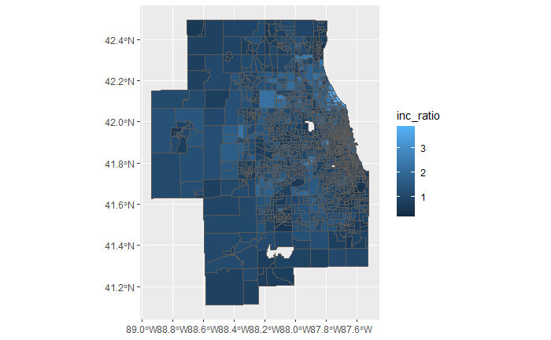

The map shows that the highest levels of inequality are visible on the eastern parts of the metropolitan region where the proportion of minorities is greatest. The coincidence of income inequality and racial segregation shows that these two forms of discrimination are intersectional.

## 4.2. Income and Racial Segregation

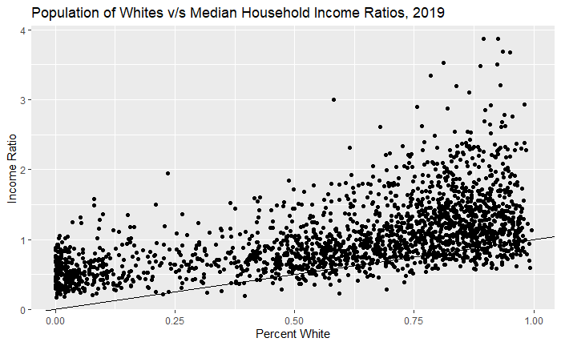

The graph shows that the greater the percentage of white population in a neighborhood, the higher the chances of income inequality between whites and minority population groups.

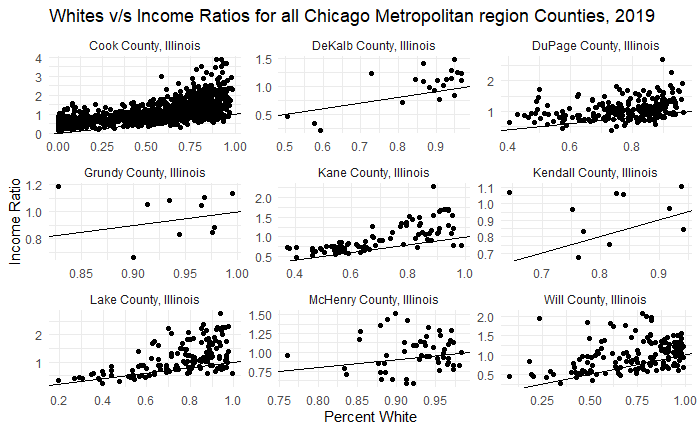

| COUNTYFP | NAME | Median_Household_Income | dissimilarity_NonWhite_White | interaction_NonWhite_White | NonWhite_Isolation |
| --- | --- | --- | --- | --- | --- |
| 031 | Cook County, Illinois | 64660 | 0.4912424 | 0.3743834 | 0.6256166 |
| 037 | DeKalb County, Illinois | 63317 | 0.3966881 | 0.7216186 | 0.2783814 |
| 043 | DuPage County, Illinois | 92809 | 0.2979487 | 0.6960930 | 0.3039070 |
| 063 | Grundy County, Illinois | 77350 | 0.2889747 | 0.8998030 | 0.1001970 |
| 089 | Kane County, Illinois | 79394 | 0.3768448 | 0.6254030 | 0.3745970 |
| 093 | Kendall County, Illinois | 96563 | 0.2377866 | 0.7677886 | 0.2322114 |
| 097 | Lake County, Illinois | 89427 | 0.3512554 | 0.6507496 | 0.3492504 |
| 111 | McHenry County, Illinois | 86799 | 0.2466268 | 0.8980792 | 0.1019208 |
| 197 | Will County, Illinois | 86961 | 0.4223635 | 0.5864017 | 0.4135983 |

## 4.3. Other Forms of Segregation

The concentration of racial minorities and low income groups in particular high density locations in the Chicago Metropolitan region demonstrate that perhaps there is concentration of poverty and housing segregation in certain parts of the city. It therefore might be interesting to observe the presence or absence of economic opportunities across counties and relate it with the income and race data that is tabulated. Some of the relevant forms of segregation would include -

1. Occupation based segregation
2. Educational level/Literacy based segregation

# 5. Conclusions

In conclusion it can be ascertained that the Metropolitan Region of Chicago demonstrates segregation. Where racial minorities are concentrated, incomes fall and interactions between people decline. Understanding how minorities, despite living in larger communities can be isolated and dissimilar from majority populations opens up a logic for deconcentration of poverty and countering segregation by enabling a greater spatial distribution of opportunity.

# Acknowledgements

The definitions for segregation indicators and the outline for the markdown notebook has been borrowed directly from Lab 13 Notebook for UP 494 Neighborhood Analysis. I express my heartfelt gratitude to Dr. Andrew Greenlee for facilitating the same.